# Русские литературные гении

Бердыева София в соавторстве с коллективом группы 20.Б02-с

## Задание 1

**Возьмем данные из трендов и узнаем, как меняется число запросов по теме со временем.**

**Найти тренд отдельно по поэзии и прозе.**

**Это следует сделать через временные ряды.**

**Проблемы:**

**1. Насколько репрезентативна выборка авторов?**

**2. Как следует обобщать результаты?**

**3. Данные по малопопулярным авторам подвержены волатильности. Следует ли всем авторам приписывать одинаковый вес или надо действовать пропорционально интересу публики?**

**4. Прийти к выводу и, возможно, предложить объяснение. Сравнить поэзию и прозу.**

Еще раз опишем задачу и её решение с начала до конца: необходимо оценить популярность запросов в поисковой системе Google, относящихся к двум группам представителей русской литературы - поэтам и прозаикам.

Как известно, среди различных эпох в русской литературе две занимают центральное место - Золотой век (некоторые литературоведы относят к нему чуть ли не весь 19 век) и Серебряный (начало 20 века). Если Серебряный век относится преимущественно к поэзии, то Золотой включал в себя как великих поэтов, так и прозаиков, поэтому для того, чтобы в нашей выборке наличествовали одновременно представители и поэзии, и прозы, и при этом из обоих периодов, разумно взять поэтов века Серебряного и прозаиков Золотого.

В случае поэтов мы вновь обращаемся к принципу максимальной вариации и подбираем представителей абсолютно различных литературнй течений (или творящих вне каких-то определённых методов): М. Цветаева, С. Есенин и В. Маяковский

С прозой немного сложней провести демаркацию, поэтому просто возьмем авторов, чьи труды имеют мировую известность, и при этом в большинстве своём являются прозаическими: Л. Толстой, Ф. Достоевский и А. Чехов

Учитывая, что наша выборка состоит всего из шести авторов, говорить о репрезентативности довольно бессмысленно. Безусловно, можно подобрать еще более вариативную комбинацию для достижения иллюзорной репрезентативности, но в целях обучения инструментарию анализа временных рядов мы сочтем наш набор приемлемым.

Отметим, что при анализе нужно учитывать сезонность популярности авторов, возникающую из-за особенностей школьной учебной прораммы по литературе, которая порождает всплеск в определенные периоды.

Для того, чтобы операционализировать конструкты “популярность поэзии” и “популярность прозы”, сделаем составной компонент для каждого из понятий, посчитав средние значения по трем авторам в месяц. Таким образом, мы ориентируемся исключительно по интересам публики, что для нас логичней как для социологов, вдобавок не имеющих столь глубоких экспертных познаний в литературоведении, чтобы браться за присваивание весов. Однако если бы мы обладали такими знаниями, можно было бы прибегнуть к методу парных сравнений. Но где-то убыло, а где-то - прибыло.

Также на всякий случай приведем описание выгружаемых данных, предоставляемое Гуглом: Числа обозначают уровень интереса к теме по отношению к наиболее высокому показателю в таблице для определенного региона и периода времени. 100 баллов означают наивысший уровень популярности запроса, 50 – уровень популярности запроса, вдвое меньший по сравнению с первым случаем. 0 баллов означает местоположение, по которому недостаточно данных о рассматриваемом запросе.

Данные, выгружаемые с помощью пакета gtrends, отличаются от тех, что мы получаем при выгрузке вручную (вторые адекватней). Поэтому ниже в чанке приведем код, который мог бы использоваться нами для получения данных, но не будет, так как ручная выгрузка безопасней.

```r
library(gtrendsR)

poets_res <- gtrends(c("Марина Ивановна Цветаева", "Владимир Маяковский", "Сергей Есенин"), geo = "RU",time = "all")
poet <- poets_res$interest_over_time

proza_res <-gtrends(keyword = c("Лев Толстой", "Фёдор Достоевский", "Антон Чехов"),  geo = "RU",time = "all")
proza <- proza_res$interest_over_time
```

А вот “настоящий” код для подгрузки и создания всего, что нужно. Сохраненные данные сложили на гитхабе.

```r
poet <- read.csv("https://raw.githubusercontent.com/sophiyaberdiyeva/Russian-literature-GTrends/main/poets_data_RU.csv", skip = 2)
proza <- read.csv("https://raw.githubusercontent.com/sophiyaberdiyeva/Russian-literature-GTrends/main/proza_data_RU.csv", skip = 2)

colnames(poet) = c('time', 'tsvetayeva','mayak','esenin')
colnames(proza)=c('time','tolstoy','dostoyevskiy','chekhov')

#Считаем столбцы со средними значениями по всем авторам
poet$means <- rowMeans(poet[,c(2:4)])
proza$means <- rowMeans(proza[,c(2:4)])

head(poet)
```

```
##      time tsvetayeva mayak esenin    means
## 1 2004-01         25    36     16 25.66667
## 2 2004-02         17    44      0 20.33333
## 3 2004-03          0    38     14 17.33333
## 4 2004-04         18     0     13 10.33333
## 5 2004-05         16    37     23 25.33333
## 6 2004-06         27     0     23 16.66667
```

```r
head(proza)
```

```
##      time tolstoy dostoyevskiy chekhov    means
## 1 2004-01      54            0      73 42.33333
## 2 2004-02       0           18      27 15.00000
## 3 2004-03      39           51       0 30.00000
## 4 2004-04      49           63      83 65.00000
## 5 2004-05      75           51      87 71.00000
## 6 2004-06      34           49      28 37.00000
```

Также создадим временные ряды для каждого из авторов и для агрег-х средних, и посмотрим на графики

### Поэзия

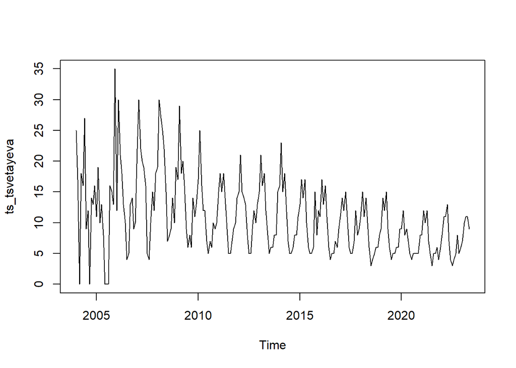

```r
ts_tsvetayeva <- ts(poet$tsvetayeva,frequency=12, start = c(2004,1),end=c(2023,5))
ts_mayak <- ts(poet$mayak,frequency=12, start = c(2004,1),end=c(2023,5))
ts_esenin <- ts(poet$esenin,frequency=12, start = c(2004,1),end=c(2023,5))
ts_poets_mean <- ts(poet$means,frequency=12, start = c(2004,1),end=c(2023,5))

#Цветаева
plot(ts_tsvetayeva)
```

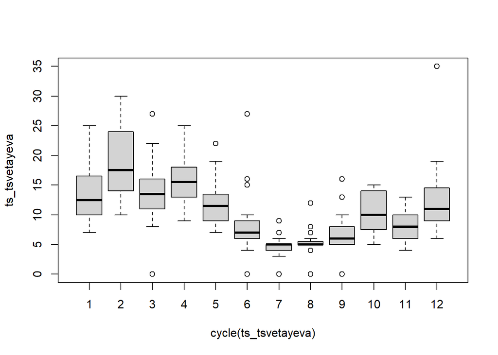

```r
boxplot(ts_tsvetayeva~cycle(ts_tsvetayeva))
```

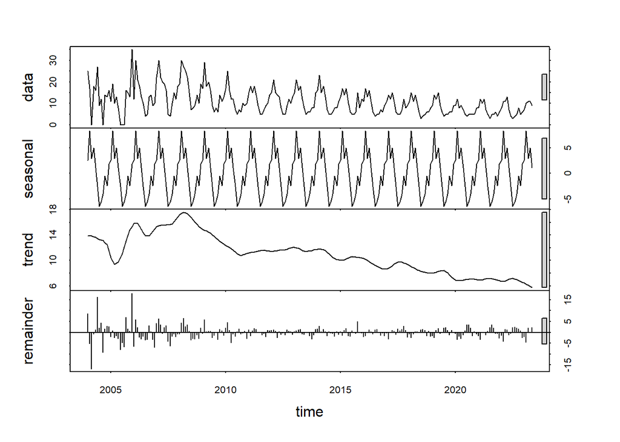

```r
dec_tsvetayeva <- decompose(ts_tsvetayeva, type="additive")
fit_tsvetayeva <- stl(ts_tsvetayeva, s.window = "periodic")
plot(fit_tsvetayeva)
```

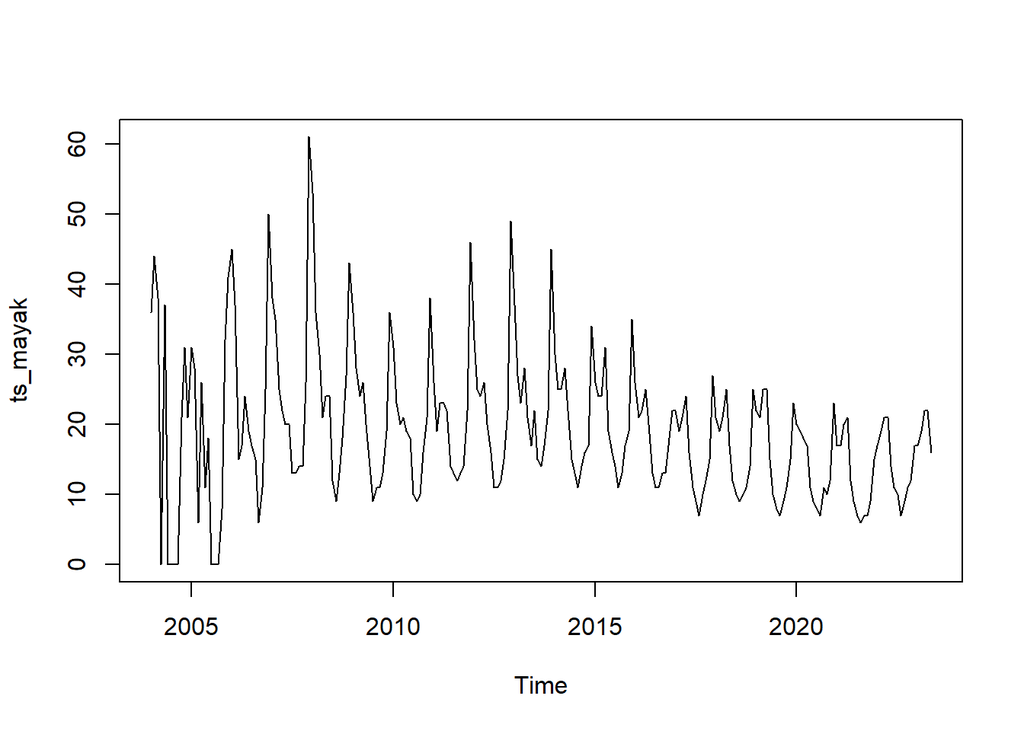

```r
#Маяковский
plot(ts_mayak)
```

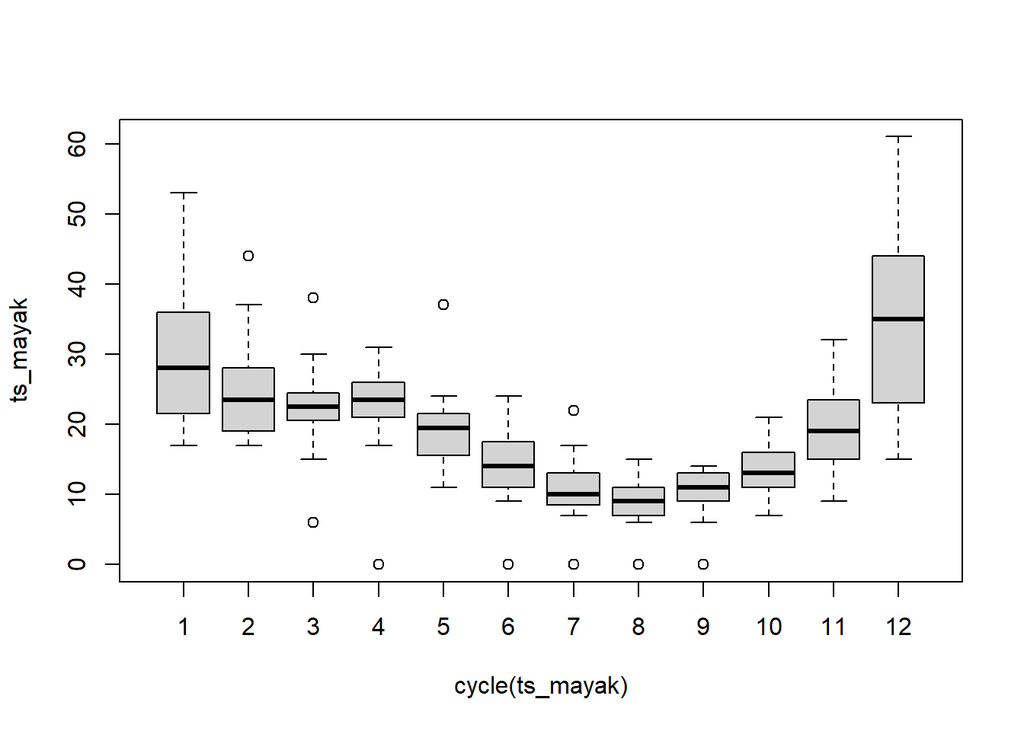

```r
boxplot(ts_mayak~cycle(ts_mayak))
```

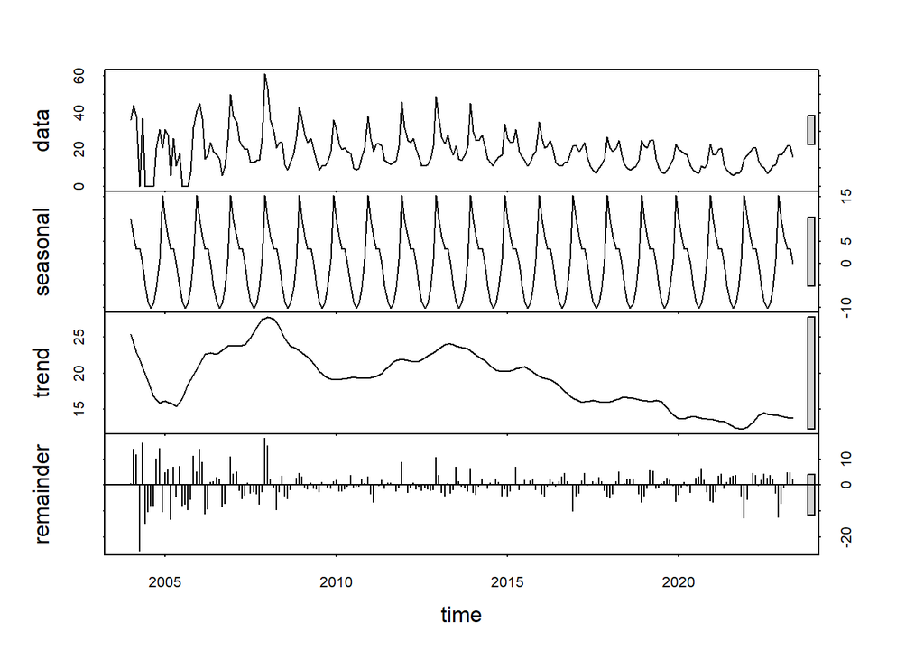

```r
dec_mayak <- decompose(ts_mayak, type="additive")
fit_mayak <- stl(ts_mayak, s.window = "periodic")
plot(fit_mayak)
```

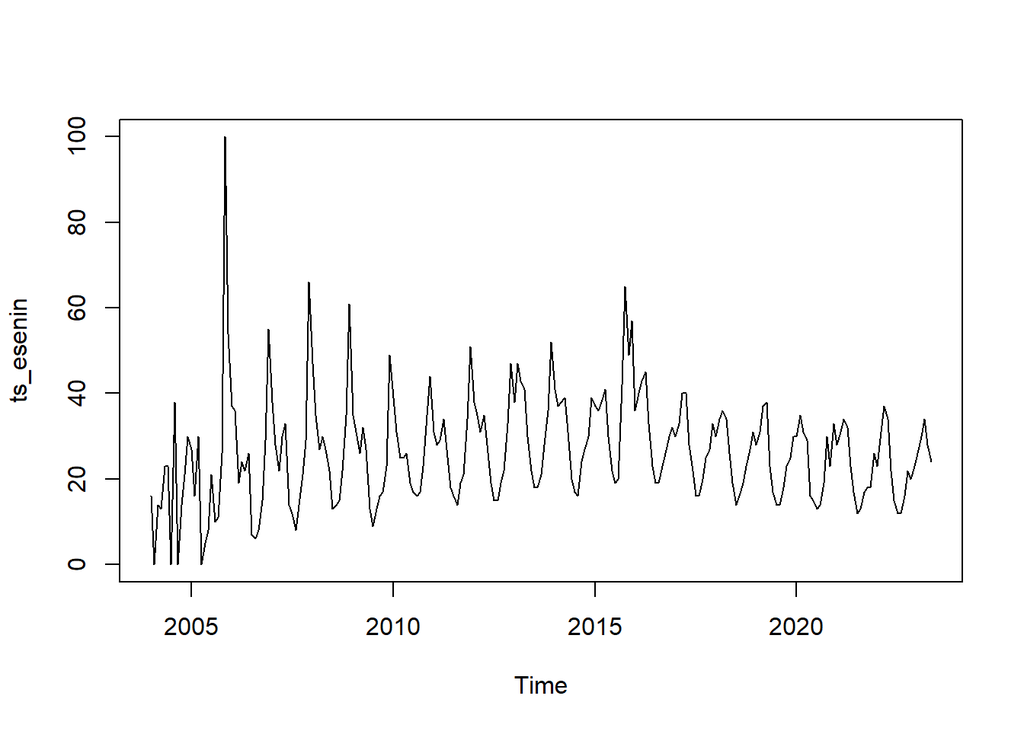

```r
#Есенин
plot(ts_esenin)
```

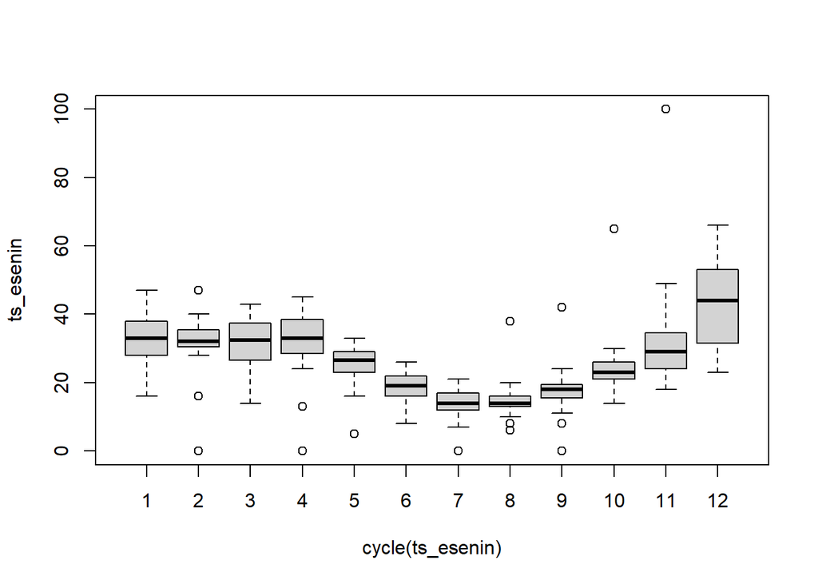

```r
boxplot(ts_esenin~cycle(ts_esenin))
```

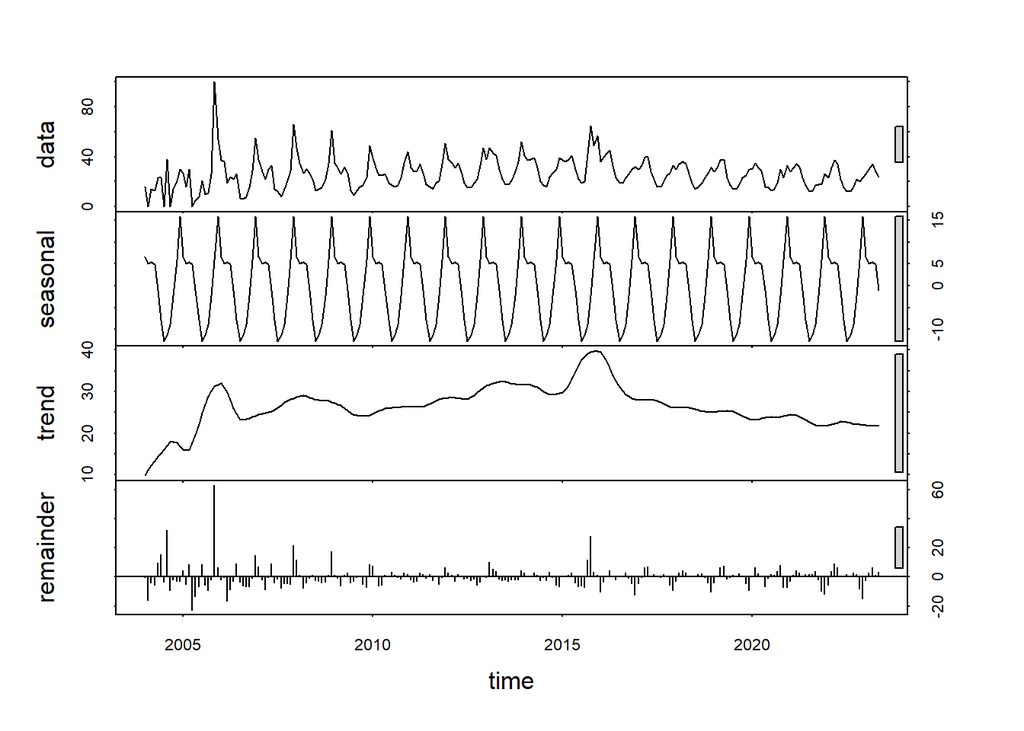

```r
dec_esenin <- decompose(ts_esenin, type="additive")
fit_esenin <- stl(ts_esenin, s.window = "periodic")
plot(fit_esenin)
```

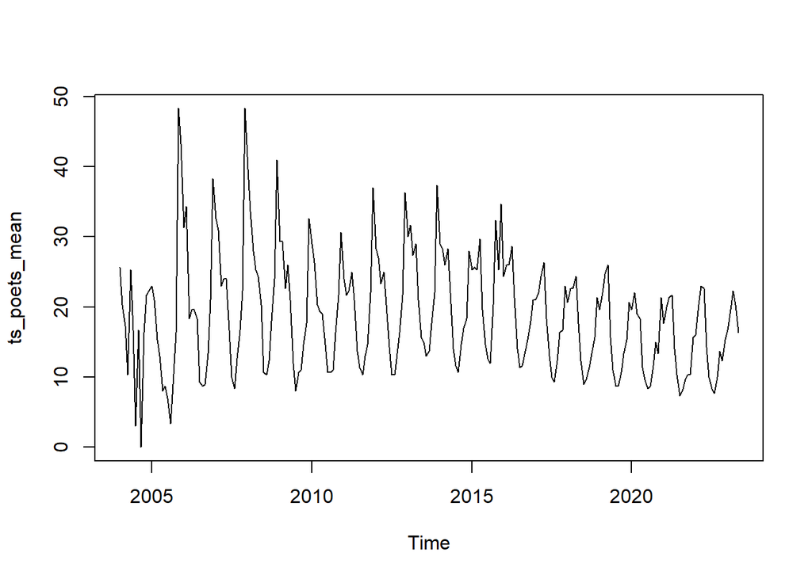

```r
#Среднее по поэтам
plot(ts_poets_mean)
```

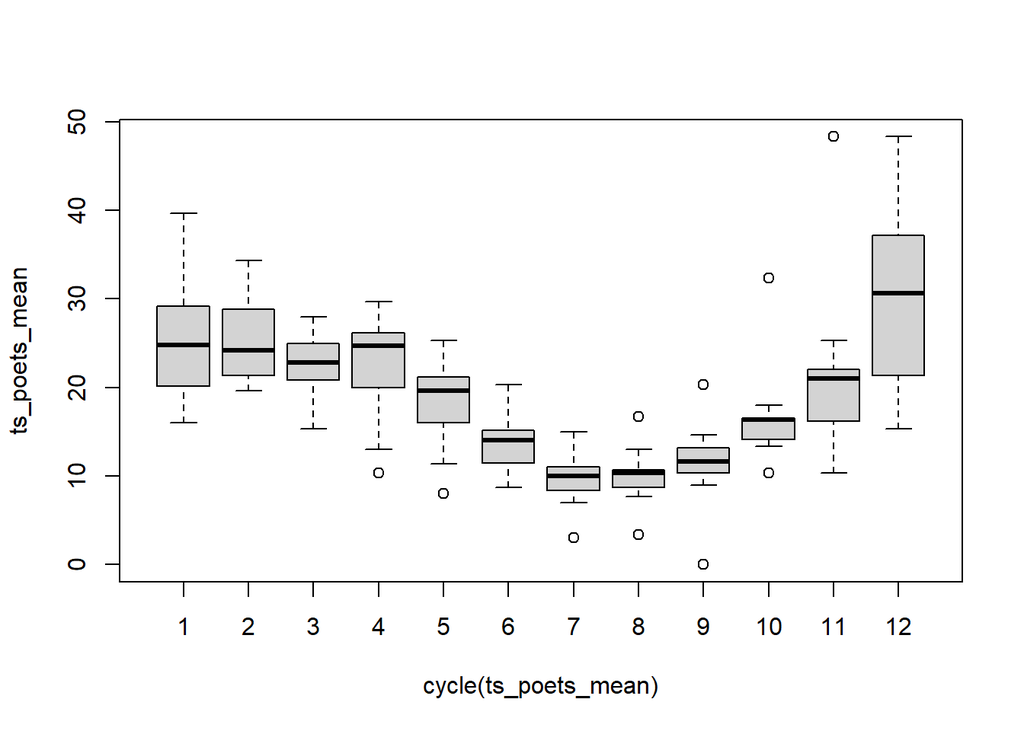

```r
boxplot(ts_poets_mean~cycle(ts_poets_mean))
```

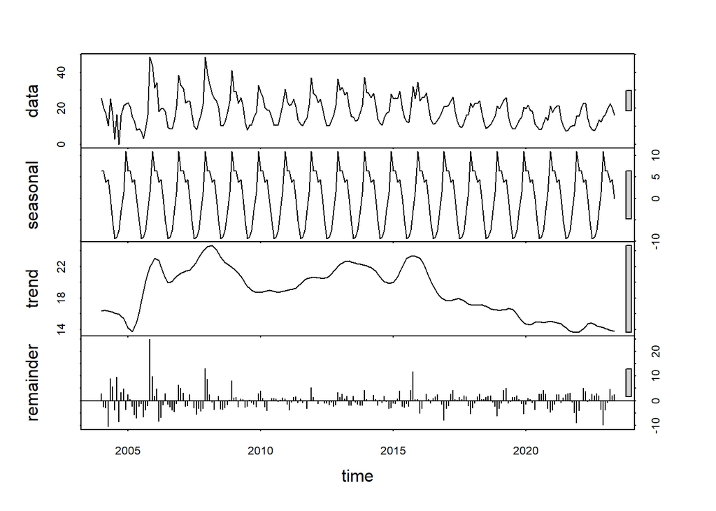

```r
dec_poets_mean <- decompose(ts_poets_mean, type="additive")
fit_poets_mean <- stl(ts_poets_mean, s.window = "periodic")
plot(fit_poets_mean)
```

### Проза

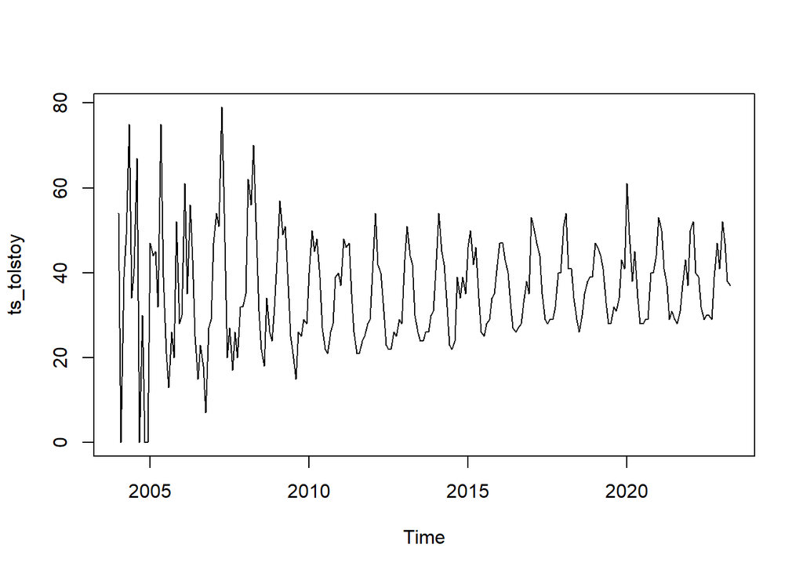

```r
ts_tolstoy <- ts(proza$tolstoy,frequency=12, start = c(2004,1),end=c(2023,4))
ts_dostoyevskiy <- ts(proza$dostoyevskiy,frequency=12, start = c(2004,1),end=c(2023,4))
ts_chekhov <- ts(proza$chekhov,frequency=12, start = c(2004,1),end=c(2023,4))
ts_proza_mean <- ts(proza$means,frequency=12, start = c(2004,1),end=c(2023,4))


#Толстой
plot(ts_tolstoy)
```

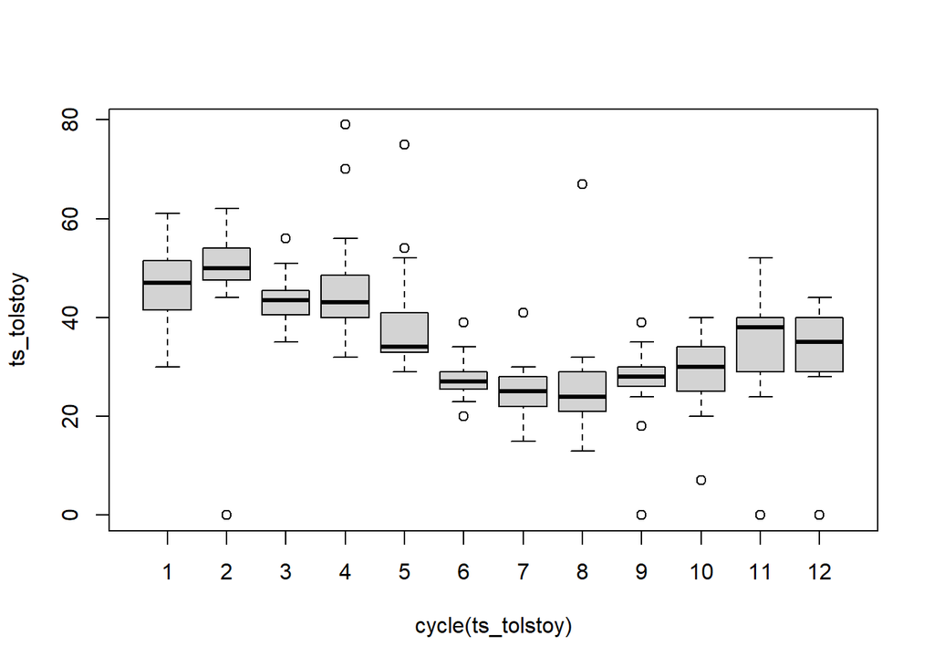

```r
boxplot(ts_tolstoy~cycle(ts_tolstoy))
```

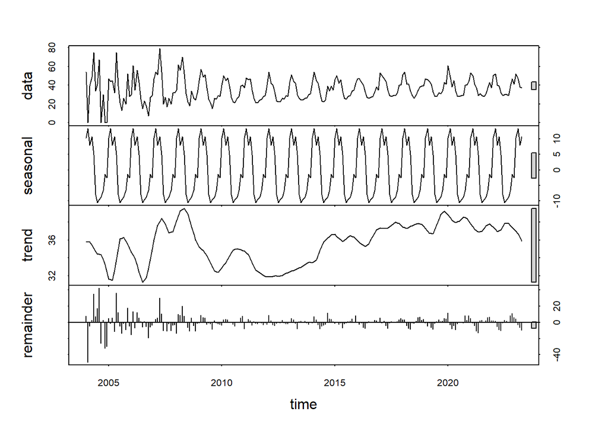

```r
dec_tolstoy <- decompose(ts_tolstoy, type="additive")
fit_tolstoy <- stl(ts_tolstoy, s.window = "periodic")
plot(fit_tolstoy)
```

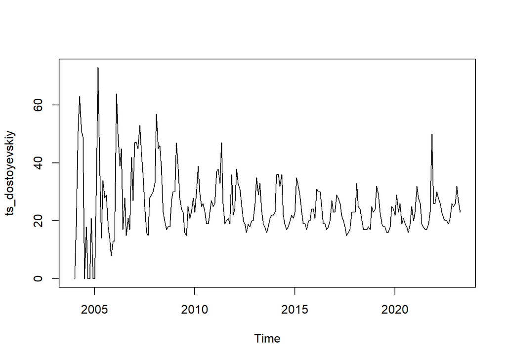

```r
#Достоевский
plot(ts_dostoyevskiy)
```

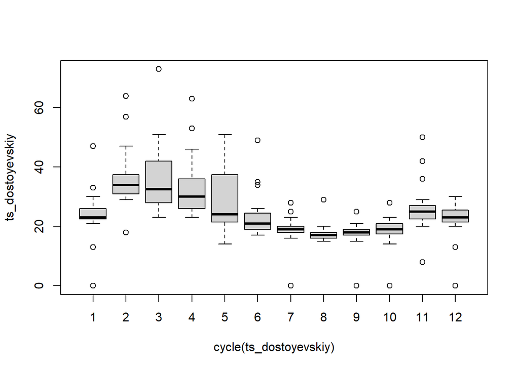

```r
boxplot(ts_dostoyevskiy~cycle(ts_dostoyevskiy))
```

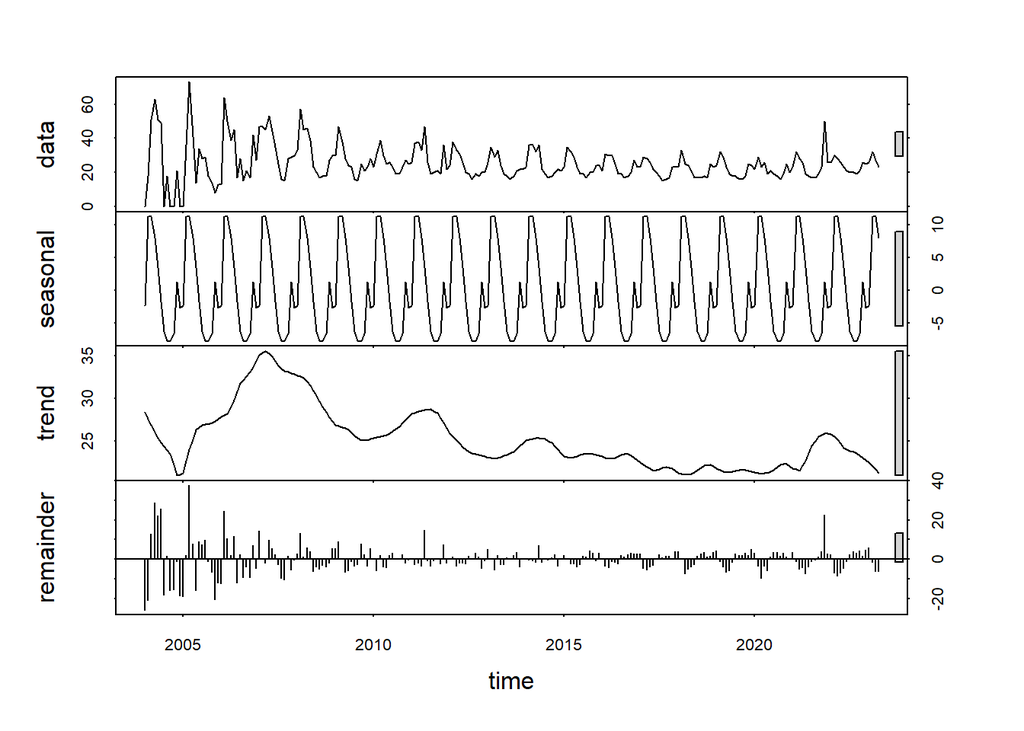

```r
dec_dostoyevskiy <- decompose(ts_dostoyevskiy, type="additive")
fit_dostoyevskiy <- stl(ts_dostoyevskiy, s.window = "periodic")
plot(fit_dostoyevskiy)
```

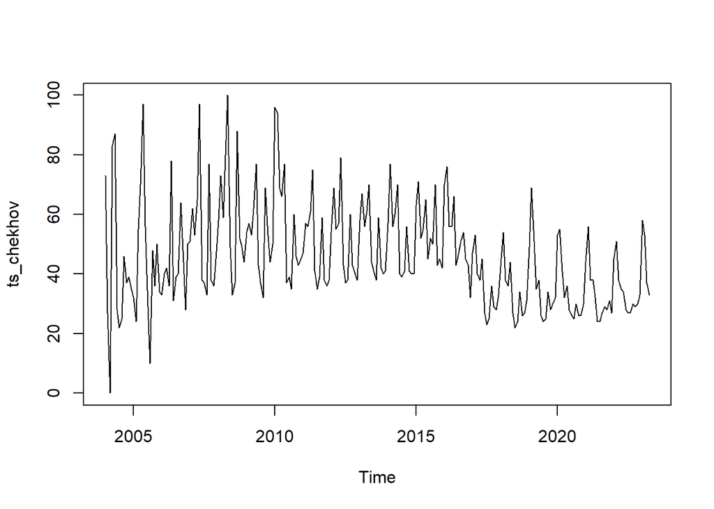

```r
#Чехов
plot(ts_chekhov)
```

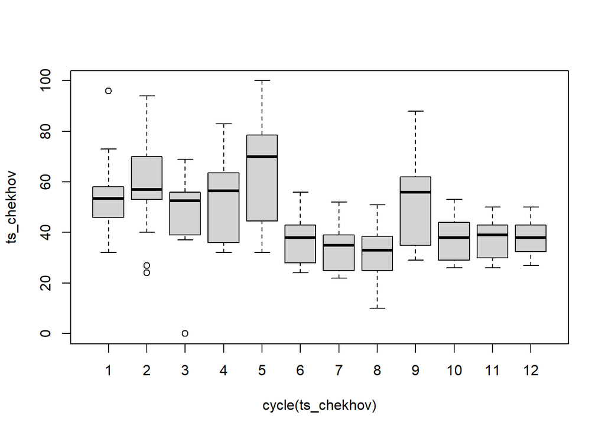

```r
boxplot(ts_chekhov~cycle(ts_chekhov))
```

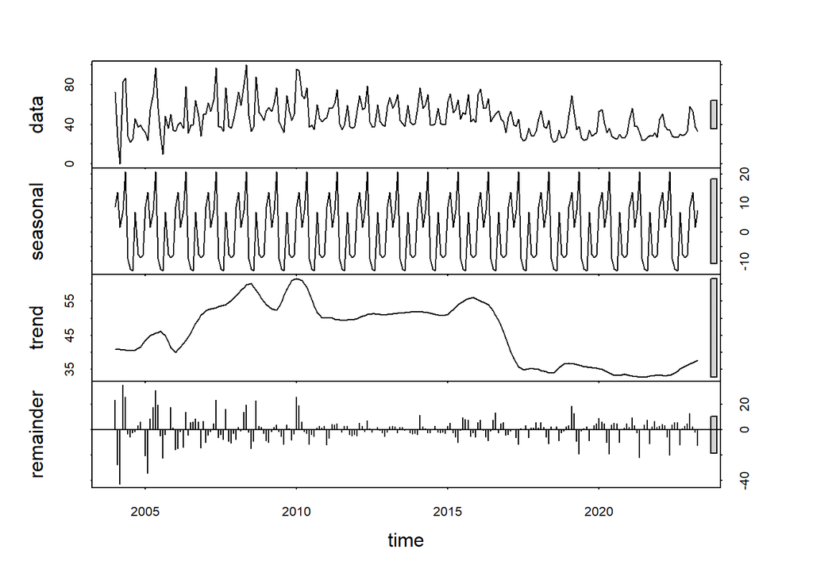

```r
dec_chekhov <- decompose(ts_chekhov, type="additive")
fit_chekhov <- stl(ts_chekhov, s.window = "periodic")
plot(fit_chekhov)
```

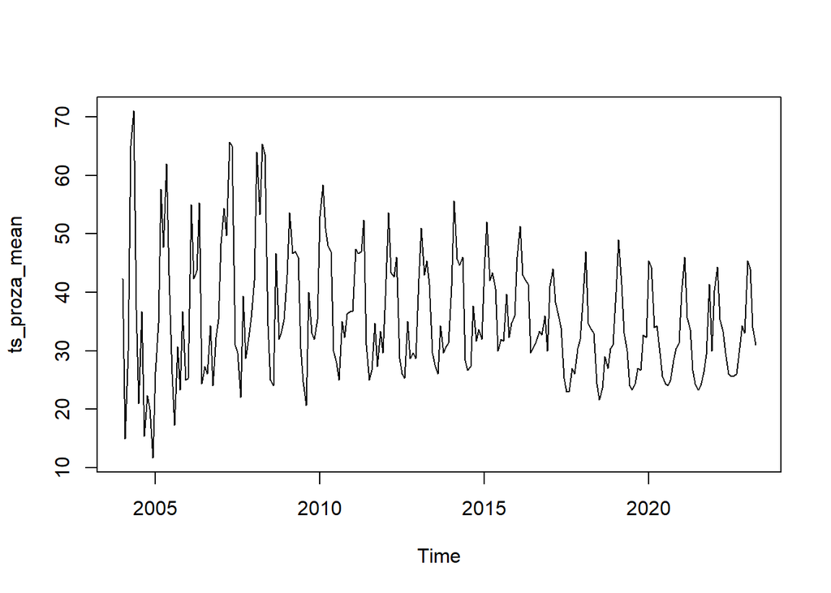

```r
#Среднее по прозаикам
plot(ts_proza_mean)
```

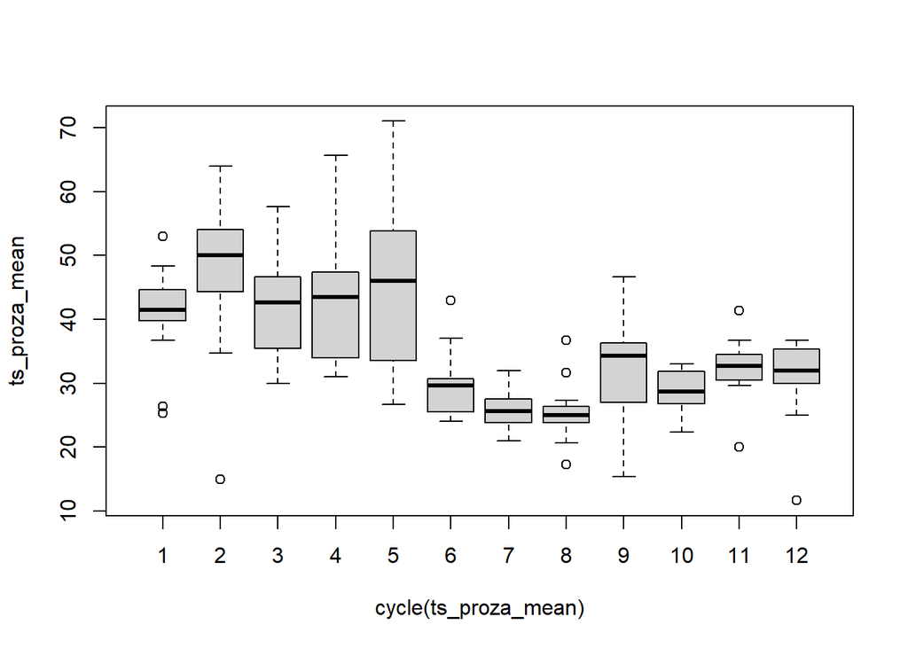

```r
boxplot(ts_proza_mean~cycle(ts_proza_mean))
```

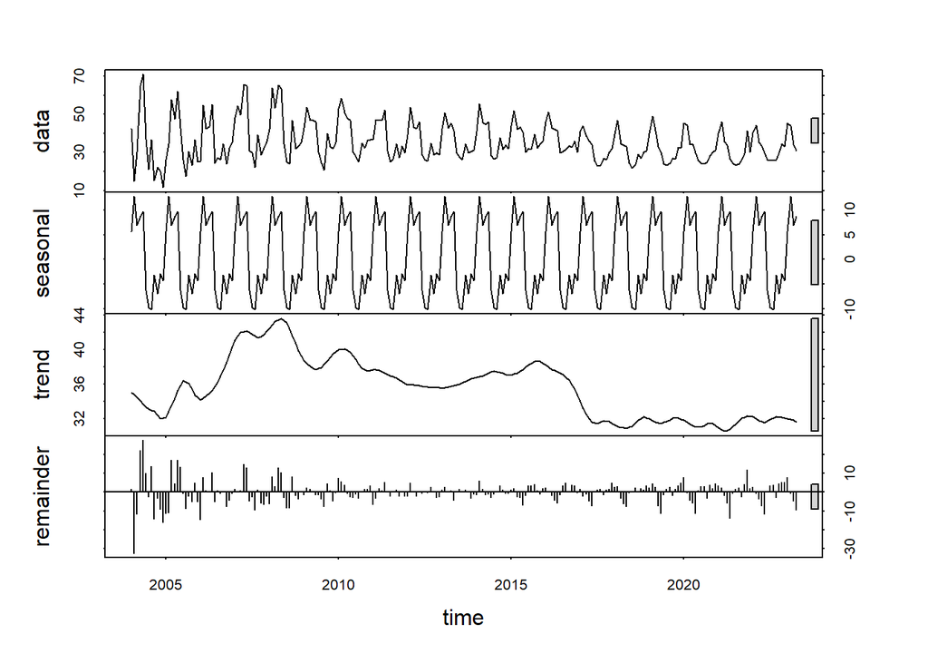

```r
dec_proza_mean <- decompose(ts_proza_mean, type="additive")
fit_proza_mean <- stl(ts_proza_mean, s.window = "periodic")
plot(fit_proza_mean)
```

В 2007-2008 годы наблюдались пики популярности запросов по сравнению с остальными. Также небольшой рост интереса происходил в 2015-2016 годах. Отметим, что 2007 был объявлен годом русского языка, и в этот период проводился комплекс мероприятий в рамках соотв. программы, а 2015 год был годом русской литературы. Также упомянем, что для большинства авторов - как для поэтов, так и для прозаиков, последние пять лет показатели внимания к ним сильно снизились по сравнению с предыдущим десятилетием. Этот тренд не коснулся только Толстого и Есенина.

## Задание 2

**Как и в прошлый раз: сделать что-то оригинальное с временными рядами, при условии выполнения задания 1.**

В дальнейшем все вычисления будем выполнять только для усредненных по всем авторам временных рядов

### Доп. графики в ggplot

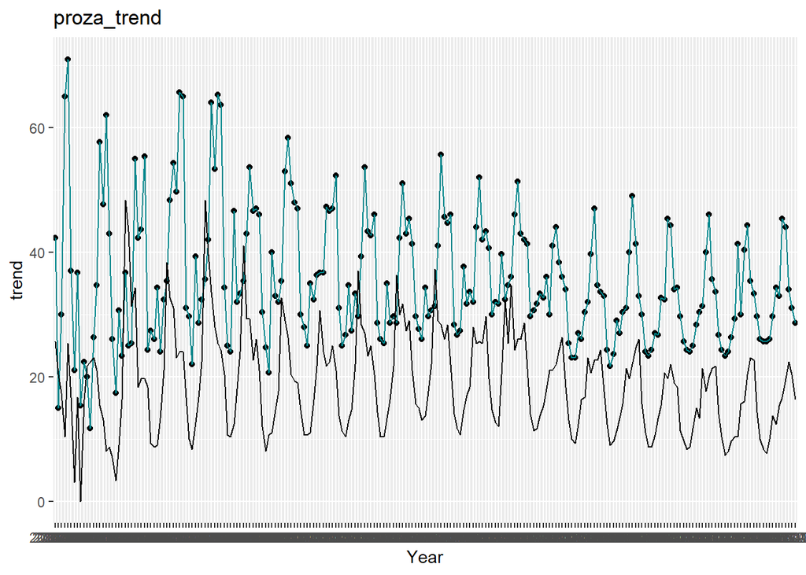

```r
library(ggplot2)

# Создание временного графика с помощью пакета ggplot2
# Здесь отдельные графики к прозе и поэзии
plot1<-ggplot(data = proza, aes(x = time, y = means, group = 1)) +geom_point()+
  geom_line( color =" turquoise4 ") +
  labs(x = "Year", y = "trend",
       title = "proza_trend")

plot2<-ggplot(data = poet, aes(x = time, y = means, group = 1)) +
  geom_point() +
  geom_line( color =" turquoise4 ") +
  labs(x = "Year", y = "trend",
       title = "poet_trend")

overlay_plot <- plot1 + geom_line(data = poet, aes(x = time, y = means, group = 1))
print(overlay_plot)
```